# Citation Diversity Tracking, Final step

- authored by: **[Lioba Enk](https://www.cbs.mpg.de/person/enk/1770355), Spokesperson for the Diversity and Inclusion Committee (MPI CBS, Leipzig, Germany)[^1]**
- last updated: **28 Jan 2026 | v3.0**

```r
# import default settings
source(file = file.path("data/configs/default_settings.R"))
```

🔵 **CASE LITERATURE REVIEW / META-ANALYSIS** : Note, default is review = 0 (see data/configs/default_settings.R). Compute the same cleanBib analysis on all the references that you review(ed), and save those **in the project folder ‘/data/ReviewLit/’**. Then activate the line of code below –> review = 1.

```r
review = 1

if (review == 1) {
  dir.create("data/ReviewLit")
  dir.create("output/OwnCitationBehav")
  dir.create("output/ReviewLit")
}
```

#### Description

**This script processes output from [`cleanBib (v1.1.3)`](https://github.com/dalejn/cleanBib)**, an open-source toolbox that allows for the automated estimation of gender by first name. This is done for the first and last authors of each of your cited references, resulting in respectively: M(male, first author)-M(male, last author), F-M, M-F, F-F. For information on how to use the toolbox, check out:

- /citation-diversity-tracking/instr/instructions_how-to-use-cleanbib.pdf

As **cleanBib output** you should have received the following files that are **input to this script**, labelled as:

- ‘predictions.csv’
- ‘cleanedBib.csv’

Those should be **saved in the project folder ‘/data/’**, before running the following sections.

This script enables (**A**) a manual check of estimated gender assignments of first names at first and last author list position of each of your cited publications (as part of your reference list), (**B**) visualizes the proportions of author pairs by itself (your reference list) and against benchmarks taken from [Dworkin et al. (Nat Neurosci 2020)](https://doi.org/10.1038/s41593-020-0658-y) and [Hefter et al. (bioRxiv 2025)](https://doi.org/10.1101/2025.02.19.638905). Lastly, it (**C**) exports your checked predictions file.

**BE AWARE:**

**`SECTIONS THAT NEED MANUAL INSERTION MARKED IN ORANGE`**

#### (_) Package dependencies

```r
library(rmarkdown)
library(insight)
library(svDialogs)
library(dplyr)
library(tidyr)
library(ggplot2)
library(ggpubr)
library(svglite)
```

#### (_) Benchmark(s)

| Author | Journal | PublicationYear | GendCat | percent |
| --- | --- | --- | --- | --- |
| Dworkin et al. | Nat Neurosci | 2020 | MM | 58.6 |
| Dworkin et al. | Nat Neurosci | 2020 | FM | 25.3 |
| Dworkin et al. | Nat Neurosci | 2020 | MF | 9.4 |
| Dworkin et al. | Nat Neurosci | 2020 | FF | 6.7 |
| Hefter et al. | BioRxiv | 2025 | MM | 39.0 |
| Hefter et al. | BioRxiv | 2025 | FM | 29.0 |
| Hefter et al. | BioRxiv | 2025 | MF | 14.0 |
| Hefter et al. | BioRxiv | 2025 | FF | 18.0 |

#### (_) Save input files in ‘/data’

Save the output files you received from using `cleanBib` as displayed in the picture below.

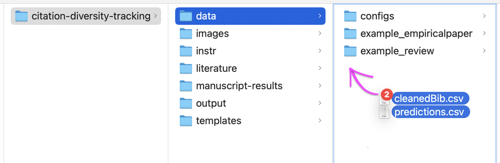

```r
inpath = "manuscript-results/2025_steinfath-et-al_hep-review/OwnCitationBehav/genderapi_cleanbib/" # "data/"
outpath = "manuscript-results/2025_steinfath-et-al_hep-review/output/" # "output/"
```

#### (_) Manuscript information

Insert the full names of the authors at first and last position in the author list (of *your own* project):

- **Format: “First_name,Last_name”**

Note: No space after comma & some letters with diacritics, e.g. äüöɫ, are not processed by `cleanBib` and therefore do not appear in their output file `predictions`!  
So, those may be gone now OR (as adviced in instruction video) written without diacritics.

```r
own_first = "Paul,Steinfath"
own_last = "Arno,Villringer"

# case shared authorship: insert, if applies
#own_first2 = "First_name,Last_name"
own_last2 = "Vadim,Nikulin"
```

As a next step, please insert the GendCat combination of your first and last authors, i.e.:

- **FF** = female first author, female last author
- **MF** = male first author, female last author
- **FM** = female first author, male last author
- **MM** = male first author, male last author

```r
GendCat_FALA = "UU" # U = unknown
```

Lastly, please insert the name of the project, and at which status the manuscript is (default: own_journal = “unpublished”, own_year = “noyear”, see data/configs/default_settings.R).

```r
own_project = "hep-review"
own_journal = "bioRxiv" # bioRxiv, J Neurosci, NeuroImage, PLOS Biolog, ...
own_year = "2025" # "2022", "2030", ...
```

🔵 **CASE LITERATURE REVIEW / META-ANALYSIS** : As default, self-citations are excluded from analyses, following [Dworkin et al. (Nat Neurosci 2020)](https://doi.org/10.1038/s41593-020-0658-y). In this case, however, we *include* self-citations.

```r
if (review == 1) {
  selfcitations_criterion = "include"
}
```

Prepare output_file…

```r
benchmark = benchmark %>%
  add_row(Author = rep(own_project,2*4),
          Journal = rep(own_journal,2*4),
          PublicationYear = rep(own_year,2*4),
          FA = rep(own_first,2*4),
          LA = rep(own_last,2*4),
          GendCat_FALA = rep(GendCat_FALA,2*4),
          GendCat = benchmark[1:8,"GendCat"],
          singleauthors = rep(c("include", "exclude"), each = 4),
          selfcitations = rep(selfcitations_criterion,8))
```

#### (_) Read [cleanBib] input

```r
predict_name = "predictions_v2"
cbib_name = "cleanedBib_v2"

predictions = read.csv(paste(inpath,predict_name,".csv",sep=""))
cleanedbib = read.csv(paste(inpath,cbib_name,".csv",sep=""))

if (review == 1) {
  predictions_ReviewLit = read.csv("manuscript-results/2025_steinfath-et-al_hep-review/ReviewLit/genderapi_cleanbib/predictions.csv")
}
```

🔵 **CASE LITERATURE REVIEW/META-ANALYSIS** Choose whether to - now & here - analyse your own citation behaviour (OwnCitationBehav - i.e., the one in the main text of your review) or gender composition across the studies you included to the review (ReviewLit).

```r
if (review == 1) {

  analyse_review_or_ownciting = "ownciting" # review

  if (analyse_review_or_ownciting == "ownciting") {
      predictions = predictions
  } else if (analyse_review_or_ownciting == "review") {
    predictions = predictions_ReviewLit
    outpath = "output/ReviewLit"
  }
}
```

Down below, you see the content of `cleanedBib`. It displays all items from your reference list (‘Article’):

- the individuals’ first names at first (‘FA’) and last position (‘LA’) of each respective author list;
- the publication title (‘Title’);
- whether it is a self-citation (‘SelfCite’ - Y/N)[^2];
- (‘CitationKey’) that includes the publication year;
- (‘UsedXref’)[^3]

| Article | FA | LA | Title | SelfCite | CitationKey | UsedXref |
| --- | --- | --- | --- | --- | --- | --- |
| 2 | Esra | Arno | Heart–brain interactions shape somatosensory perception and evoked potentials | N | al_heartbrain_2020 | N |
| 3 | Luca | Scott | ICLabel: An automated electroencephalographic independent component classifier dataset and website | N | pion-tonachini_iclabel_2019 | N |
| 4 | Steven | Nicholas | How to get statistically significant effects in any ERP experiment (and why you shouldn't) | N | luck_how_2017 | N |
| 5 | Steven | Steven | An introduction to the event-related potential technique | N | luck_introduction_2014 | N |
| 6 | Kat | Danielle | Gender imbalance in citations most pronounced in high-impact neuroscience journals | N | hefter_gender_2025 | N |
| 7 | Vera | Martin | Short-Term Fasting and Ingestion of Caloric Drinks Affect Heartbeat-Evoked Potentials and Autonomic Nervous System Activity in Males | N | flasbeck_short-term_2021 | N |
| 8 | Juan | Juan | Suppression of the cardiac electric field artifact from the heart action evoked potential | N | perez_suppression_2005 | N |
| 9 | Gerhard | Friedrich | Cardiac field effects on the EEG | N | dirlich_cardiac_1997 | N |
| 10 | Amanda | Simone | Interoceptive cardiac expectations to emotional stimuli predict visual perception. | N | marshall_interoceptive_2020 | N |
| 11 | Andre | Claus | Distinctive body perception mechanisms in high versus low symptom reporters: A neurophysiological model for medically-unexplained symptoms | N | schulz_distinctive_2020 | N |

[output cut: 101 more lines]

Down below, you see `predictions` which contains the following information:

- (‘CitationKey’) - same as in `cleanedBib`
- either the first or last author’s full name for each cited publication (‘Author’), e.g. Muster,Kim
- the estimated binary gender assignment, i.e. female/male, followed by an accuracy value[^4] (‘Gender’), e.g. female,98
- (‘W’)[^5]
- (‘A’)[^6]
- The resulting estimated gender category per author pair, i.e. M-M, F-M, M-F, F-F (‘GendCat’)

| X | CitationKey | Author | Gender | W | A | GendCat |
| --- | --- | --- | --- | --- | --- | --- |
| 0 | al_heartbrain_2020 | Esra,Al | female,97 | 0 0.114722\nName: nh_white, dtype: float32 | 0.885278300 |  |
| 1 | al_heartbrain_2020 | Arno,Villringer | male,99 | 0 0.838583\nName: nh_white, dtype: float32 | 0.161417470 | femalemale |
| 2 | pion-tonachini_iclabel_2019 | Luca,Pion-Tonachini | male,98 | 0 0.537089\nName: nh_white, dtype: float32 | 0.462911220 |  |
| 3 | pion-tonachini_iclabel_2019 | Scott,Makeig | male,100 | 0 0.990739\nName: nh_white, dtype: float32 | 0.009261099 | malemale |
| 4 | luck_how_2017 | Steven,Luck | male,99 | 0 0.967853\nName: nh_white, dtype: float32 | 0.032147042 |  |
| 5 | luck_how_2017 | Nicholas,Gaspelin | male,100 | 0 0.91908\nName: nh_white, dtype: float32 | 0.080920175 | malemale |
| 6 | luck_introduction_2014 | Steven,Luck | male,99 | 0 0.967853\nName: nh_white, dtype: float32 | 0.032147042 |  |
| 7 | luck_introduction_2014 | Steven,Luck | male,99 | 0 0.967853\nName: nh_white, dtype: float32 | 0.032147042 | malemale |
| 8 | hefter_gender_2025 | Kat,Hefter | female,95 | 0 0.965952\nName: nh_white, dtype: float32 | 0.034048280 |  |
| 9 | hefter_gender_2025 | Danielle,Bassett | female,96 | 0 0.732539\nName: nh_white, dtype: float32 | 0.267461150 | femalefemale |

[output cut: 212 more lines]

#### (A) Check assignments

We wish to **(A.1)** check whether we can find explicit information about the gender of an author, especially in the case of low accuracy, and **(A.2)** delete all self-citations (that is any publication with either/or or both of the first and last authors’ names).

#### (A.1) Gender

**Take a look at the assignments per author**. We advise you to pay special attention to those that have an *assignment probability value of ≤.80*.

| X | Author | Gender |
| --- | --- | --- |
| 0 | Esra,Al | female,97 |
| 1 | Arno,Villringer | male,99 |
| 2 | Luca,Pion-Tonachini | male,98 |
| 3 | Scott,Makeig | male,100 |
| 4 | Steven,Luck | male,99 |
| 5 | Nicholas,Gaspelin | male,100 |
| 6 | Steven,Luck | male,99 |
| 7 | Steven,Luck | male,99 |
| 8 | Kat,Hefter | female,95 |
| 9 | Danielle,Bassett | female,96 |

[output cut: 212 more lines]

**Which strategy us applied?** Default is it to check all references with assignment probability value of ≤.80 (check_80_and_lower = 1, see data/configs/default_settings.R). You can yet also activate *one* of the lines below (check_all = 1 | check_none = 1).

```r
#check_all = 1
#check_none = 1
```

**Independent of their accuracy value**: Do you wish to check specific names?[^7]

```r
# If you want this, insert + activate line below...
selected_names = c("R,Team", "PRISMA,Group")
```

**Down below** you now see all names that need manual checking by you, here (default strategy): **those with accuary value ≤ 80 (default)**.

|  | CitationKey | Author | Gender | Gender_check |
| --- | --- | --- | --- | --- |
| 18 | marshall_interoceptive_2020 | Simone,Schtz-Bosbach | male,66 | yes |
| 61 | zaccaro_attention_2024 | Andrea,Zaccaro | female,54 | yes |
| 81 | botvinik-nezer_reproducibility_2023 | Rotem,Botvinik-Nezer | female,50 | yes |
| 127 | kim_heartbeat_2019 | Jaejoong,Kim | male,57 | yes |
| 133 | kumral_attenuation_2022 | Deniz,Kumral | male,62 | yes |
| 144 | moher_systematic_2009 | PRISMA,Group | male,57 | yes |
| 146 | niizeki_interaction_1993 | Yoshimi,Miyamoto | female,68 | yes |
| 153 | sassenhagen_cluster-based_2019 | Jona,Sassenhagen | male,63 | yes |
| 164 | steegen_increasing_2016 | Wolf,Vanpaemel | male,80 | yes |
| 193 | noauthor_citation_2023 | None,None | unknown,0 | yes |

[output cut: 4 more lines]

Following an online search on those names (or else strategy), **insert your response in the window below, as follows:**

- **Options:** “male” “diverse” “female”, “unknown”

```r
check_predictions$Gender_posthoc = c(

  "female", "male", "female", "male", "female", "unknown", "unknown", "male", "male", "unknown",
  "unknown", "unknown", "unknown", "male"

  )
```

*Post-hoc note*: Why appear some names multiple times? To save you time, it would be nicer to have each author(’s name) only once. The issue here is that Non-ASCII characters (such as áşıñ) are deleted in the cleanBib output files (v1.1.3). Therefore it can happen that one author is listed with different incomplete names. I therefore decided that all entries should be checked.

**Now, are you happy with the results? (below)**

- If yes –> proceed.
- If not –> insert new response in previous section and re-run.

|  | CitationKey | Author | Gender | Gender_check | Gender_posthoc |
| --- | --- | --- | --- | --- | --- |
| 18 | marshall_interoceptive_2020 | Simone,Schtz-Bosbach | male,66 | yes | female |
| 61 | zaccaro_attention_2024 | Andrea,Zaccaro | female,54 | yes | male |
| 81 | botvinik-nezer_reproducibility_2023 | Rotem,Botvinik-Nezer | female,50 | yes | female |
| 127 | kim_heartbeat_2019 | Jaejoong,Kim | male,57 | yes | male |
| 133 | kumral_attenuation_2022 | Deniz,Kumral | male,62 | yes | female |
| 144 | moher_systematic_2009 | PRISMA,Group | male,57 | yes | unknown |
| 146 | niizeki_interaction_1993 | Yoshimi,Miyamoto | female,68 | yes | unknown |
| 153 | sassenhagen_cluster-based_2019 | Jona,Sassenhagen | male,63 | yes | male |
| 164 | steegen_increasing_2016 | Wolf,Vanpaemel | male,80 | yes | male |
| 193 | noauthor_citation_2023 | None,None | unknown,0 | yes | unknown |

[output cut: 4 more lines]

**If happy,**

- the manually inserted variable **‘Gender_posthoc’** (see table above) is stored
- variable **‘GendCat_posthoc’** (i.e. dyadic gender information per publication) is created

in `predictions`.

```r
# Insert manual Gender_posthoc
predictions$Gender_posthoc = NA
predictions[(predictions$Gender_check == "no"),"Gender_posthoc"] =
  substring(predictions[(predictions$Gender_check == "no" | is.na(predictions$Gender_check)),"Gender"], 1, 1)
for (i in 1:nrow(check_predictions)){
  predictions[(predictions$Author == check_predictions$Author[i]),
            "Gender_posthoc"] = substring(check_predictions$Gender_posthoc[i],1,1)
}
#GendCat_posthoc
predictions$GendCat_posthoc = NA
predictions[(predictions$GendCat != ""), "GendCat_posthoc"] = paste(
  predictions[predictions$GendCat == "","Gender_posthoc"], #FA
  predictions[predictions$GendCat != "", "Gender_posthoc"],sep="") #LA
```

Final output file `predictions`:

| X | CitationKey | Author | Gender | Gender_check | Gender_posthoc | GendCat_posthoc |
| --- | --- | --- | --- | --- | --- | --- |
| 0 | al_heartbrain_2020 | Esra,Al | female,97 | no | f | NA |
| 1 | al_heartbrain_2020 | Arno,Villringer | male,99 | no | m | fm |
| 2 | pion-tonachini_iclabel_2019 | Luca,Pion-Tonachini | male,98 | no | m | NA |
| 3 | pion-tonachini_iclabel_2019 | Scott,Makeig | male,100 | no | m | mm |
| 4 | luck_how_2017 | Steven,Luck | male,99 | no | m | NA |
| 5 | luck_how_2017 | Nicholas,Gaspelin | male,100 | no | m | mm |
| 6 | luck_introduction_2014 | Steven,Luck | male,99 | no | m | NA |
| 7 | luck_introduction_2014 | Steven,Luck | male,99 | no | m | mm |
| 8 | hefter_gender_2025 | Kat,Hefter | female,95 | no | f | NA |
| 9 | hefter_gender_2025 | Danielle,Bassett | female,96 | no | f | ff |

[output cut: 212 more lines]

🔵 **CASE LITERATURE REVIEW/META-ANALYSIS** and use this tool, the following section…

- identifies references cited in the main text (own_citation_behaviour) that are also in the reviewed literature (reviewed_body)
- identifies references cited in the main text that are not part of the reviewed body
- calculates the proportion of the reviewed body that is cited in the main text

This is done to distinguish between (1) references from the reviewed literature and (2) additional sources cited in the review’s main text.

```r
if (review == 1) {

  if (analyse_review_or_ownciting == "ownciting") {

    # get number of reviewed papers (size of reviewed body)
  n_reviewed = length(unique(predictions_ReviewLit$CitationKey))

  #create dataframes (for own citation behaviour!)
  predictions_own_ReviewLit = semi_join(predictions,
                                        predictions_ReviewLit,
                                        by = c("CitationKey", "Author"))
  predictions_own_new = anti_join(predictions,
                                  predictions_ReviewLit,
                                  by = c("CitationKey", "Author"))

  # get number of reviewed papers cited in main text (i.e., OwnCitationBehav & part of ReviewLit)
  n_reviewed_cited = length(unique(predictions_own_ReviewLit$CitationKey))

  # percent
  percent_reviewed_cited = round(n_reviewed_cited / n_reviewed * 100,3)

  cat(paste0(
    "**", n_reviewed_cited, " of ", n_reviewed,
    " (", percent_reviewed_cited, " %)**",
    " reviewed studies (ReviewLit) were also cited in the main text (OwnCitationBehav)."
    ))

  }
}
```

```
## **35 of 132 (26.515 %)** reviewed studies (ReviewLit) were also cited in the main text (OwnCitationBehav).
```

#### (A.2) Self-citations

|  | X | CitationKey | Author | Gender | W | A | GendCat | Gender_check | Gender_posthoc | GendCat_posthoc | SelfCite_posthoc |
| --- | --- | --- | --- | --- | --- | --- | --- | --- | --- | --- | --- |
| 1 | 0 | al_heartbrain_2020 | Esra,Al | female,97 | 0 0.114722\nName: nh_white, dtype: float32 | 0.88527830 |  | no | f | NA | N |
| 2 | 1 | al_heartbrain_2020 | Arno,Villringer | male,99 | 0 0.838583\nName: nh_white, dtype: float32 | 0.16141747 | femalemale | no | m | fm | Y |
| 77 | 76 | al_cardiac_2023 | Esra,Al | female,97 | 0 0.114722\nName: nh_white, dtype: float32 | 0.88527830 |  | no | f | NA | N |
| 78 | 77 | al_cardiac_2023 | Vadim,Nikulin | male,99 | 0 0.915539\nName: nh_white, dtype: float32 | 0.08446117 | femalemale | no | m | fm | Y |
| 133 | 132 | kumral_attenuation_2022 | Deniz,Kumral | male,62 | 0 0.475677\nName: nh_white, dtype: float32 | 0.52432346 |  | yes | f | NA | N |
| 134 | 133 | kumral_attenuation_2022 | Arno,Villringer | male,99 | 0 0.838583\nName: nh_white, dtype: float32 | 0.16141747 | malemale | no | m | fm | Y |
| 165 | 164 | steinfath_validating_2025 | Paul,Steinfath | male,99 | 0 0.97645\nName: nh_white, dtype: float32 | 0.02354986 |  | no | m | NA | Y |
| 166 | 165 | steinfath_validating_2025 | Arno,Villringer | male,99 | 0 0.838583\nName: nh_white, dtype: float32 | 0.16141747 | malemale | no | m | mm | Y |
| 221 | 220 | villringer_brainbody_2025 | Arno,Villringer | male,99 | 0 0.838583\nName: nh_white, dtype: float32 | 0.16141747 |  | no | m | NA | Y |
| 222 | 221 | villringer_brainbody_2025 | Michael,Gaebler | male,99 | 0 0.982167\nName: nh_white, dtype: float32 | 0.01783341 | malemale | no | m | mm | N |

```r
if (review == 0) {
  predictions = predictions[!(predictions$CitationKey %in% df$CitationKey),]
}
```

#### (_) Unknown citations

Be reminded that those are first names that had an assignment probability below .80, and could not assigned through a manual search. Those can also be references authored by a consortium (e.g., one of the Enigma Groups), or software references (such as ‘R Team’).[^8]

|  | X | CitationKey | Author | Gender | W | A | GendCat | Gender_check | Gender_posthoc | GendCat_posthoc | SelfCite_posthoc |
| --- | --- | --- | --- | --- | --- | --- | --- | --- | --- | --- | --- |
| 143 | 142 | moher_systematic_2009 | David,Moher | male,99 | 0 0.97498\nName: nh_white, dtype: float32 | 0.02502029 |  | no | m | NA | N |
| 144 | 143 | moher_systematic_2009 | PRISMA,Group | male,57 | 0 0.19984\nName: nh_white, dtype: float32 | 0.80016020 | malemale | yes | u | mu | N |
| 145 | 144 | niizeki_interaction_1993 | Kyuichi,Niizeki | male,100 | 0 0.026998\nName: nh_white, dtype: float32 | 0.97300190 |  | no | m | NA | N |
| 146 | 145 | niizeki_interaction_1993 | Yoshimi,Miyamoto | female,68 | 0 0.081807\nName: nh_white, dtype: float32 | 0.91819316 | malefemale | yes | u | mu | N |
| 193 | 192 | noauthor_citation_2023 | None,None | unknown,0 | 0 0.860154\nName: nh_white, dtype: float32 | 0.13984607 |  | yes | u | NA | N |
| 194 | 193 | noauthor_citation_2023 | None,None | unknown,0 | 0 0.860154\nName: nh_white, dtype: float32 | 0.13984607 | unknownunknown | yes | u | uu | N |
| 213 | 212 | r_core_team_r_2025 | R,Team | unknown,0 | 0 0.893909\nName: nh_white, dtype: float32 | 0.10609134 |  | yes | u | NA | N |
| 214 | 213 | r_core_team_r_2025 | R,Team | unknown,0 | 0 0.893909\nName: nh_white, dtype: float32 | 0.10609134 | unknownunknown | yes | u | uu | N |

#### (_) Single-authored citations

|  | X | CitationKey | Author | Gender | W | A | GendCat | Gender_check | Gender_posthoc | GendCat_posthoc | SelfCite_posthoc | SingleAuthor |
| --- | --- | --- | --- | --- | --- | --- | --- | --- | --- | --- | --- | --- |
| 168 | 167 | sweet_new_2021 | Deborah,Sweet | female,98 | 0 0.902352\nName: nh_white, dtype: float32 | 0.09764759 | femalefemale | no | f | ff | N | 1 |
| 8 | 7 | luck_introduction_2014 | Steven,Luck | male,99 | 0 0.967853\nName: nh_white, dtype: float32 | 0.03214704 | malemale | no | m | mm | N | 1 |
| 106 | 105 | elson_examining_2019 | Malte,Elson | male,99 | 0 0.789981\nName: nh_white, dtype: float32 | 0.21001865 | malemale | no | m | mm | N | 1 |
| 132 | 131 | kruschke_bayesian_2021 | John,Kruschke | male,99 | 0 0.995685\nName: nh_white, dtype: float32 | 0.00431496 | malemale | no | m | mm | N | 1 |
| 156 | 155 | shannon_mathematical_1948 | Claude,Shannon | male,89 | 0 0.707595\nName: nh_white, dtype: float32 | 0.29240507 | malemale | no | m | mm | N | 1 |
| 186 | 185 | armstrong_when_2014 | Richard,Armstrong | male,99 | 0 0.91817\nName: nh_white, dtype: float32 | 0.08183052 | malemale | no | m | mm | N | 1 |
| 212 | 211 | perakakis_heplab_2019 | Pandelis,Perakakis | male,98 | 0 0.89927\nName: nh_white, dtype: float32 | 0.10073040 | malemale | no | m | mm | N | 1 |
| 216 | 215 | rousselet_using_2025 | Guillaume,Rousselet | male,99 | 0 0.03032\nName: nh_white, dtype: float32 | 0.96968025 | malemale | no | m | mm | N | 1 |
| 220 | 219 | yoder_peakfinderx0_2026 | Nathanael,Yoder | male,100 | 0 0.813489\nName: nh_white, dtype: float32 | 0.18651049 | malemale | no | m | mm | N | 1 |

#### (B) Plot

Load plot settings …

```r
source(file = file.path("data/configs/plot_settings.R"))
```

Plotting …

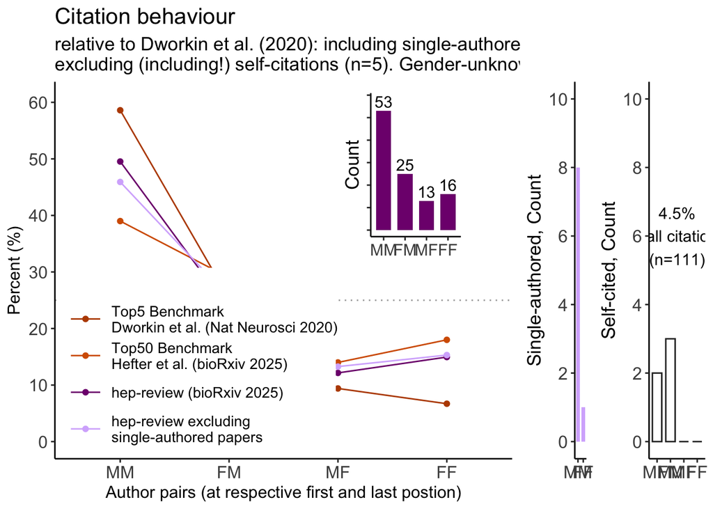

```r
# bar plot (counts)
p2_data = benchmark[benchmark$Author == own_project & benchmark$singleauthors == "include",]
p2 = ggplot(data=p2_data,
            aes(x=GendCat, y=count)) +
  geom_bar(stat="identity", fill = p_colours[3], width= 0.7) +
  geom_text(aes(label=count), vjust=-0.3, size=4) +
  scale_x_discrete(labels= c("MM","FM","MF","FF")) +
  scale_y_continuous(breaks = c(seq(0,p2_y_seqmax,10)),limits = c(0,(max(p2_data$count)+5))) +
  labs(y="Count") +
  p2_theme


# joint plot (line plot against benchmark + p2)
p3 = ggplot(benchmark, aes(x=GendCat, y=percent, group=p_results, color=p_results)) +
    geom_hline(yintercept=25, color = ref_colour, linetype = "dotted")+
  geom_line(aes(color=p_results))+
  geom_point(aes(color=p_results))+
  scale_y_continuous(breaks = c(seq(0,p3_seqmax, 10)),
                     limits = c(0,max(benchmark$percent)+2)) +
  p3_theme +
  annotation_custom(
    ggplotGrob(p2),
    xmin = p3_annotating_p2_inside_parameters[1],
    xmax = p3_annotating_p2_inside_parameters[2],
    ymin = p3_annotating_p2_inside_parameters[3],
    ymax = p3_annotating_p2_inside_parameters[4]
    )
if (review == 0) {
  p3 = p3 +
    p3_labels +
    p3_scale_color_manual
} else if (review == 1) {
  if (analyse_review_or_ownciting == "ownciting") {
    p3 = p3 +
    p3_labels_review_ownciting +
    p3_scale_color_manual_review_ownciting
  } else if (analyse_review_or_ownciting == "review") {
    p3 = p3 +
    p3_labels_review_lit +
    p3_scale_color_manual_review_ownciting
  }

}

p4 = ggplot(data=summary_singleauthors, aes(x=X1, y=X2)) +
  geom_bar(stat="identity", fill = p_colours[4], width= 0.7)+
  scale_y_continuous(breaks = c(seq(0,p45_seqmax,2)), limits = c(0,max_addon_plots+2))+
  labs(y="Single-authored, Count")+
  p45_theme

p5 = ggplot(data=summary_selfcite, aes(x=X1, y=X2)) +
  geom_bar(stat="identity", col = p5_colour, fill = "white", width= 0.7)+
  scale_y_continuous(breaks = c(seq(0,p45_seqmax,2)), limits = c(0,max_addon_plots+2))+
  labs(y="Self-cited, Count")+
  annotate(geom="text",
           x=2.5,
           y=sum(summary_selfcite$X2)+1,
           label=paste(as.character(
             round( length(unique(df$CitationKey)) /
                      (sum(your_summary$your_count) + nrow(n_unknown_pairs)) * 100,2)),
                       "%","\nof all citations","\n(n=",
             as.character(sum(your_summary$your_count) + nrow(n_unknown_pairs)),")", sep=""),
              color="black", size=rel(4))+
    p45_theme


ggarrange(p3, p4, p5, ncol = 3, widths = c(7,1,1.6), align = "hv")
```

```r
ggsave(width = 12, height = 6,
  paste(outpath,
        format(Sys.time(), '%Y%m%d'),"_",own_project,
        "_citationdiversitytracking_plot.svg",sep=""))
```

#### (C) Save in ‘/output’

```r
if (nrow(df) != 0) {
  write.csv(df,paste(outpath,
                     format(Sys.time(), '%Y%m%d'),"_",own_project,
                     "_citationdiversitytracking_selfcitations.csv",sep=""))
}
if (nrow(singleauthors) != 0) {
  write.csv(singleauthors,paste(outpath,
                                format(Sys.time(), '%Y%m%d'),"_",own_project,
                                "_citationdiversitytracking_singleauthors.csv",sep=""))
}

write.csv(predictions,paste(outpath,
                            format(Sys.time(), '%Y%m%d'),"_",own_project,
                            "_citationdiversitytracking_",predict_name,"_checked.csv",sep=""))


write.csv(benchmark,paste(outpath,
                          format(Sys.time(), '%Y%m%d'),"_",own_project,
                         "_citationdiversitytracking_summary.csv",sep=""))
```

| Author | Journal | PublicationYear | FA | LA | GendCat_FALA | GendCat | singleauthors | selfcitations | percent | p_results | count |
| --- | --- | --- | --- | --- | --- | --- | --- | --- | --- | --- | --- |
| Dworkin et al. | Nat Neurosci | 2020 | Jordan D.,Dworkin | Danielle S.,Bassett | NA | MM | included | excluded | 58.60000 | 1 | NA |
| Dworkin et al. | Nat Neurosci | 2020 | Jordan D.,Dworkin | Danielle S.,Bassett | NA | FM | included | excluded | 25.30000 | 1 | NA |
| Dworkin et al. | Nat Neurosci | 2020 | Jordan D.,Dworkin | Danielle S.,Bassett | NA | MF | included | excluded | 9.40000 | 1 | NA |
| Dworkin et al. | Nat Neurosci | 2020 | Jordan D.,Dworkin | Danielle S.,Bassett | NA | FF | included | excluded | 6.70000 | 1 | NA |
| Hefter et al. | BioRxiv | 2025 | Kat,Hefter | Dani S.,Bassett | NA | MM | included | excluded | 39.00000 | 2 | NA |
| Hefter et al. | BioRxiv | 2025 | Kat,Hefter | Dani S.,Bassett | NA | FM | included | excluded | 29.00000 | 2 | NA |
| Hefter et al. | BioRxiv | 2025 | Kat,Hefter | Dani S.,Bassett | NA | MF | included | excluded | 14.00000 | 2 | NA |
| Hefter et al. | BioRxiv | 2025 | Kat,Hefter | Dani S.,Bassett | NA | FF | included | excluded | 18.00000 | 2 | NA |
| hep-review | bioRxiv | 2025 | Paul,Steinfath | Arno,Villringer | UU | MM | include | include | 49.53271 | 3 | 53 |
| hep-review | bioRxiv | 2025 | Paul,Steinfath | Arno,Villringer | UU | FM | include | include | 23.36449 | 3 | 25 |

[output cut: 6 more lines]

#### (D.1) *Contribute with your output?*

*What is required?*

**It is either the first or last author that uploads the output.**

**Click here (Survey)**  
Note (09.08.2025): will be updated and published soon again. Please reach out if interested!

#### (D.2) *Support this initiative?*

*Click here for more information (Survey)*  
Note (09.08.2025): will be updated and published soon again. Please reach out if interested!

**DONE!**

#### Acknowledgements

My thanks go to my colleagues [Paul Steinfath](https://www.cbs.mpg.de/person/steinfath/371395), [Nick Kapralov](https://www.cbs.mpg.de/employees/kapralov) and [Magda Gippert](https://www.cbs.mpg.de/employees/gippert) for their valuable feedback, recommendations, and interest. Finally, heartfelt thanks to all members of the Diversity & Inclusion Committee of the MPI CBS in Leipzig — especially to [Jo Finnemann](https://jjf33.user.srcf.net)! 🦋

[^1]: https://www.cbs.mpg.de/diversity-inclusion-committee; diversity-list@cbs.mpg.de
[^2]: Self-citation: the first and last author of your checked project being at first or last position on any of the cited publications
[^3]: *no clue what that means*
[^4]: As described in `cleanBib`, a service provided by gender-api.com is used for the binary gender assignment. It is probabilistic. The accuracy value (0 *not accurate* - 100 *accurate*) is defined as follows [Gender API (n.d.). [Frequently asked questions: What happens if a name can be male as well as female?](https://gender-api.com/en/frequently-asked-questions#:~:text=The%20value%20is%20calculated%20by,conjugated%20to%20a%20specific%20gender.) (Accessed on 04 January 2024)]: *‘The value is calculated by the number of records in our database. For example, if we have 100 samples of a name, 96 are female, and 4 are male, the accuracy is 96% (or a . 96 probability). A low accuracy indicates that this name is probably used by multiple genders and cannot be conjugated to a specific gender.’*
[^5]: Estimated binary assignment to be white (vs. non-white/column A), see [Bertolero et al., (bioRxiv, 2020)](https://doi.org/10.1101/2020.10.12.336230). Visit the Q&A section of citation-diversity-tracking for my explanation on how I *don’t* include this piece of information in my analysis.
[^6]: Estimated binary assignment to be non-white (vs. white/column W), see [Bertolero et al. (bioRxiv, 2020)](https://doi.org/10.1101/2020.10.12.336230). Visit the Q&A section of citation-diversity-tracking for my explanation on how I *don’t* include this piece of information in my analysis.
[^7]: *Why may this be relevant?* You may have noticed above that a name has been *incorrectly* assigned to a binary gender category with >.80 probability. Then you can add it in here to insert the correct value.
[^8]: Possible improvement in the future: Disentangle references with authoring individuals/names vs. software/data references.